# How the GW OSPO Uses Skill.md and AI

## How the GW OSPO Uses Skill.md and AI

GW Open Source Program Office

David Lippert

## GW Open Source Program Office

Overview

**Based in the Library**, serving all GW students, faculty, staff, and researchers.

**Mission:** foster a culture of open collaboration through open source software, open data, and open access.

[ospo.gwu.edu](https://ospo.gwu.edu/)

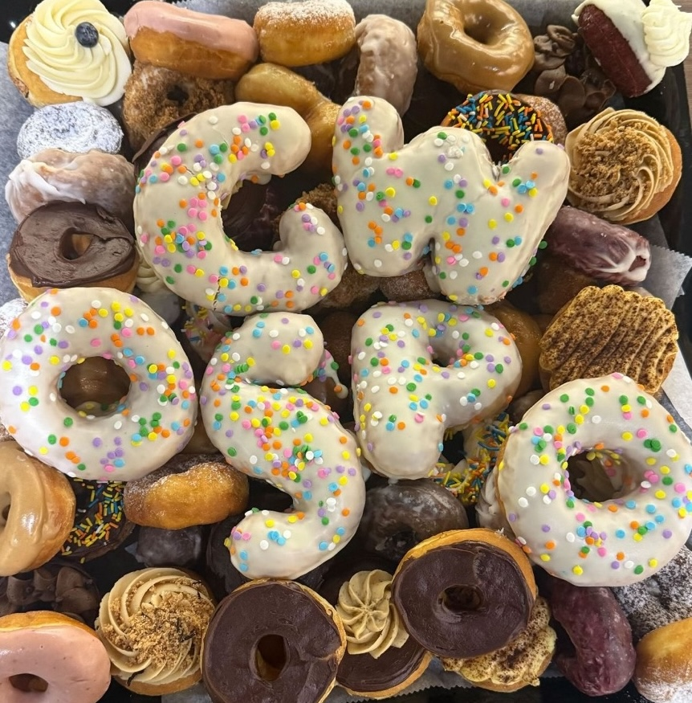

## What we do

Overview

Educate

- What is open source?
- How do I make research outputs public?
- Can open source help me get a job?

Connect

- Open source as the glue to help academia, industry, government, & other orgs work together
- Network: CURIOSS, CHAOSS, OFAI, UN, Nava, Civic Tech DC, CMS, TODO, …

Support

- Consultations
- Workshops
- Grant support
- Initiatives
- Events

## Events

Overview

- [GW OSCON](https://ospo.gwu.edu/open-source-conference-gw-oscon-2027), March 31 to April 1, 2027
- GW Coders Lunch & Learn
- Hackathons and the Halloween Robot Challenge
- Student ambassadors and awards

[figure not shown]

2025/2026 GW OSPO Ambassadors

## A design skill and a review process

Part 1

How AI helps us make on-brand materials.

## From first draft to final

Part 1 · Design skill

→

[figure not shown]

Final

## Review process

Part 1 · Design skill

1 · Generate

Our internal OSPO Marketing & Comms team creates a flyer, newsletter, website, or other output.

2 · Review

The design skill checks the graphic against the brand and layout principles.

3 · Human decides

A person reads the report, fixes priorities, iterates, and approves.

## What the review checks

Part 1 · Review process

Proximity

Related things sit together.

Alignment

Every element lines up with something.

Repetition

One visual system, used consistently.

Contrast

The main point is obvious.

## How a review is written

Part 1 · Review process

Read**One-line read** and what the eye sees first, second, third.

Start here**What’s working.** Two or three real strengths, before any criticism.

Must fixBreaks a brand rule or accessibility. Not taste.

Should fixHarder to read than it needs to be.

ConsiderA suggestion. Take it or leave it.

Next**If you only do three things:** a short checklist.

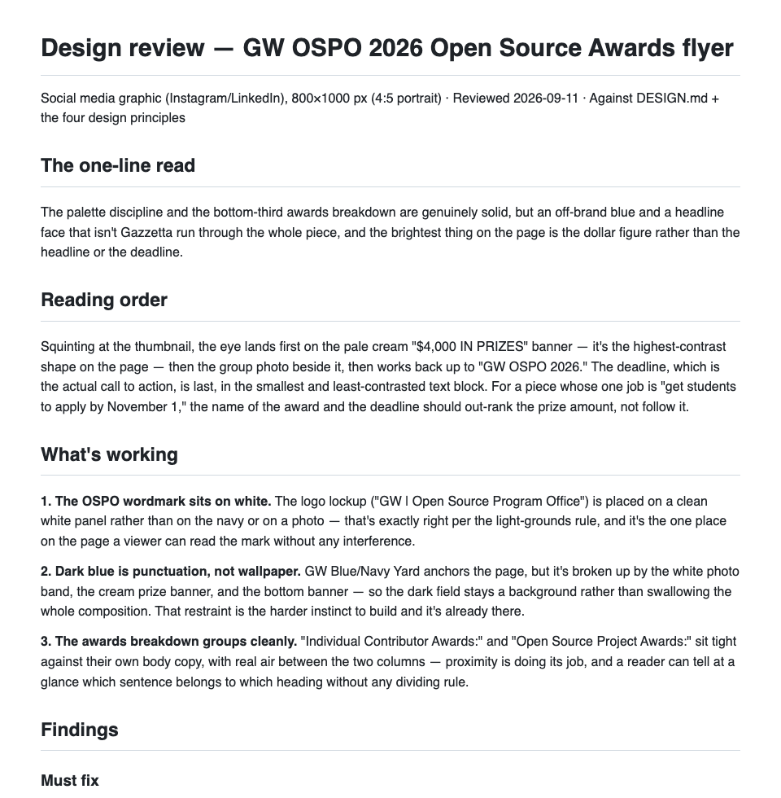

## Review finding 1: an off-brand blue

Part 1 · Review of the original

**1****2**

A flat blue that isn’t in the GW palette runs through the page.

- Measured **#0096D5**, not Potomac **#0075C8**
- White text on it: **3.32:1**, large text only
- On Potomac: **4.80:1**, passes at any size
- Fix: swap both areas to Potomac

## Review finding 2: no Gazzetta

Part 1 · Review of the original

**1****2****3****4****5**

Every headline is set in a serif face. Gazzetta appears nowhere.

- Five headline moments, one serif face
- Source Serif should stay rare: one word or a pull quote
- Fix: reset all five in Gazzetta
- No Gazzetta? Use Avenir Next Bold, not the serif

## Review finding 3: hierarchy

Part 1 · Review of the original

**1****2****3**

The loudest shape is the prize amount. The deadline is last.

- Reading order: prize banner, photo, title, and only then the deadline
- The hero block is centered; the rest is left-aligned
- Fix: left-align the hero and give the deadline more weight
- Or quiet the cream prize banner

## From first draft to final

Part 1 · Design skill

→

[figure not shown]

Final

## Inside the design review repo

Part 1 · The skill

SKILL.md The instructions Claude follows: how to look at a design and how to write the report.

brand/ `DESIGN.md` is the rulebook, `palette.json` the colors, `profile.md` who the reviews are for.

references/ `brand-checks.md`, `design-principles.md`, and `report-format.md`: what to check and how to write it.

scripts/ `contrast.py` and `palette_audit.py` measure; `rasterize.py` turns PDFs into images.

Lives in `.claude/skills/gw-design-review/`. A ready-made `gw-design-review.zip` is included for claude.ai.

## Using a skill with Claude

Part 1 · The skill

claude.ai

1. Download `gw-design-review.zip`
2. Settings, then Capabilities, then Skills
3. Upload skill (don’t unzip)

Claude desktop, Cowork, Code

1. Download the repo (Code, then Download ZIP)
2. Point Claude at the folder
3. Nothing to install

Any other AI tool

1. Attach the four text files
2. Ask for the report
3. No setup, no auto contrast checks

**Then ask:** “Review this poster against our brand guidelines. It’s a printed 11×17 for the OSCON call for papers.”

## Where to find the skills

Part 1 · The repos

gwospo-brand Brand assets and the design system for the GW OSPO, including the OSCON palette and patterns.

github.com/gw-ospo/gwospo-brand

gw-design-review The design reviewer. Checks a flyer, poster, deck, or page against the brand and the four principles.

github.com/gw-ospo/gw-design-review

gw-presentation Builds GW-branded slides. The newest piece, and it helped build this deck.

github.com/gw-ospo/gw-presentation

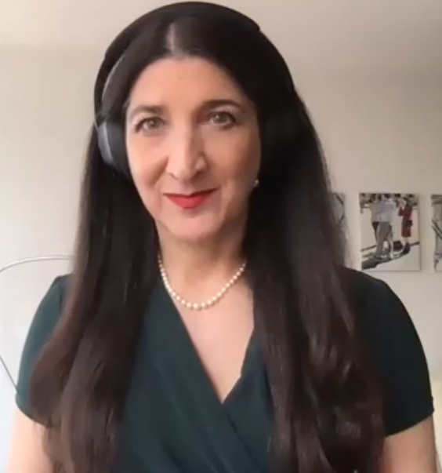

All three skills created by **Professor Lorena Barba**

## Quarto and AI

Part 2

Research from Professor John P. Helveston.

## Quarto disentangles content and format

Part 2 · Professor John P. Helveston, posit::conf(2026)

## Quarto disentangles content and format, continued

Part 2 · Professor John P. Helveston, posit::conf(2026)

## Same content, four formats - output tokens

Part 2 · Quarto

1× Quarto

[figure not shown]

1.8× PDF (LaTeX)

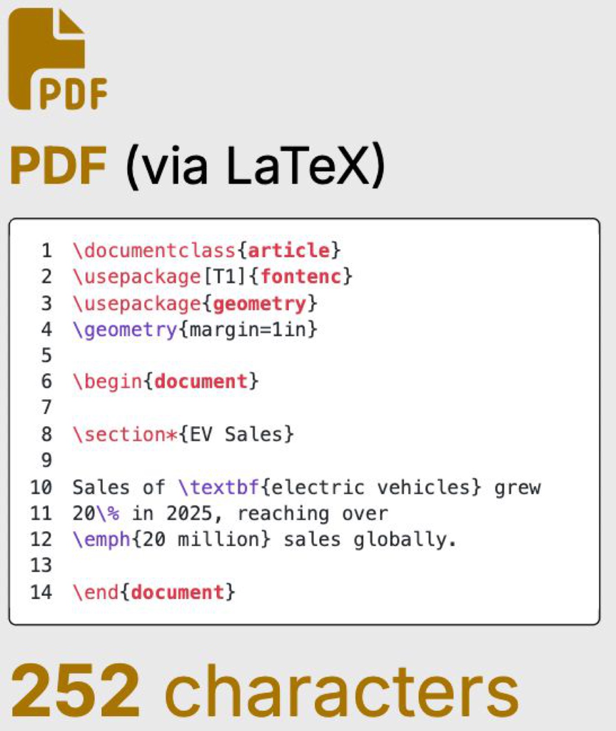

4× HTML

[figure not shown]

7.2× Word

[figure not shown]

## Three benefits with AI

Part 2 · Quarto

Modularity

Content and format live apart, so AI can edit one without breaking the other.

Efficiency

Plain text is short. Fewer characters means fewer tokens, lower cost, faster edits.

Correctness

Small readable files are easy for people to check and for Git to diff.

## This deck is a quarto markdown file

Part 2 · Quarto

**index.qmd** holds the words. **gw-theme.scss** holds the look.

Change the theme and every slide changes. Change a sentence and the design is untouched.

Source

github.com/gw-ospo/todo-ai-agent-presentation

## Other AI work

Part 3

Research, policy, and the pop-up AI museum.

## AI research

Part 3 · Other AI work

TAI · Trustworthy AI

- Openness as a path to trust
- NSF TRAILS: AI skills and open source literacy

OFAI · Open Forum for AI

- CMU, UT Austin, Georgia Tech, Purdue, GW
- Research, prototypes, policy, community, talent

## Open source research game

Part 3 · TAI

## Open Source, AI, and Art

Part 3 · Other AI work

good first contributions

[figure not shown]

digital art student stickers

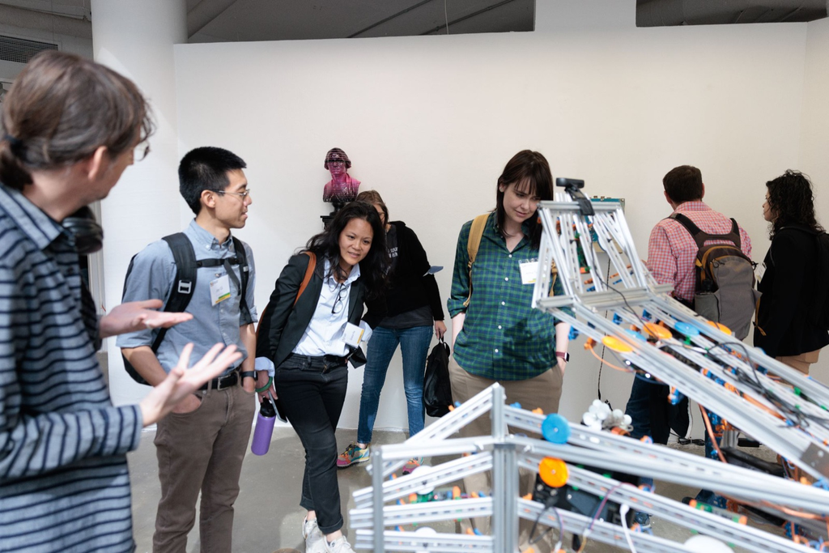

open source art show

## Thank you

Questions?

[ospo.gwu.edu](https://ospo.gwu.edu/) · ospo@gwu.edu · github.com/gw-ospo

Let’s collaborate on research projects and provide opportunities for students together.

## Backup

Backup slides

Open source discovery and curation.

## Open Source Discovery & Curation

Backup · Discovery

ORB · Open Source Repository Browser

- Built by the UC OSPO Network
- Maps and classifies open source projects across UC campuses
- Makes projects easier to find for researchers, students, and collaborators
- Raises visibility, recognition, and funding potential

[ORB on GitHub](https://github.com/UC-OSPO-Network/orb-showcase)

OSPO Radar · with Software Heritage

- Two-year, Sloan Foundation funded project
- Institutional portal and software assets dashboard for OSPOs
- Builds on CodeMeta metadata and Software Heritage archiving
- Includes an Open Science helpdesk and training

[OSPO-RADAR launch post](https://www.softwareheritage.org/2025/04/02/ospo-radar-project-launch/)